# Class 2 Assignment - CartoCSS - Styling Features

## Concepts & Themes:

This week’s assignment will encompass the following concepts, some of which will be previewed during the **Class 2**:

- CartoCSS general syntax
- CartoCSS default statements
- CartoCSS conditional statements
- CartoCSS classification, aka *TurboCarto*

## Class 2 Links:

- [Agenda](https://gis-nspe-tns.github.io/GIS_NINT5423_spring_2023/agendas/c2_agenda_spring_23_NINT5423.html)
- [Lecture 2](https://gis-nspe-tns.github.io/GIS_NINT5423_spring_2023/lectures/lecture.2/index.html)
- [Assignment 2 (This Document)](https://gis-nspe-tns.github.io/GIS_NINT5423_spring_2023/assignments/c2_assignment_spring_23_NINT5423.html)
- [Lecture Demonstration](https://gis-nspe-tns.github.io/GIS_NINT5423_spring_2023/demos/c2.lecture.demo.html)
- [Class 2 Demonstration Code](https://gis-nspe-tns.github.io/GIS_NINT5423_spring_2023/demo_code/c2_cartocss_demo_code.css)
- [Class 2 CartoCSS Video Guide](https://vimeo.com/743973654)

## Class 2 CartoCSS Video Guide:

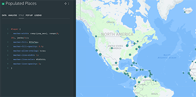

## CartoCSS Reference PDFs:

- [CartoCSS Starter Guide](https://gis-nint4523.s3.us-east-2.amazonaws.com/pdf-materials/cartocss-reference.pdf)
- [CartoCSS Advanced Guide](https://gis-nint4523.s3.us-east-2.amazonaws.com/pdf-materials/advanced-cartocss-reference.pdf)
- [CARTO CartoCSS Complete Documentation Guide Online](https://carto.com/developers/styling/cartocss/)

## Example Student Project Deliverable:

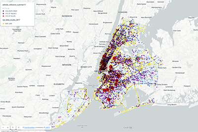

LINK to Map

## Step #1 - Data Acquisition:

This week’s assignment will consist of two parts. First, an interactive CARTO map utilizing CartoCSS; and second, a short synopsis write-up of the map’s development process. The submission will be one PDF document to Canvas. You will copy the link of the final deliverable map from CARTO to the PDF writeup.

To start, you will need two layers of spatial data. These can be a combination of points, lines or polygon features. For instance, in the example map project note above, the two layers are as follows:

- Layer 1 - [NYC Bike Lanes (polylines)](https://data.cityofnewyork.us/Transportation/New-York-City-Bike-Routes/7vsa-caz7)
- Layer 2 - [Filtered NYC Crash Data](https://data.cityofnewyork.us/Public-Safety/Motor-Vehicle-Collisions-Crashes/h9gi-nx95)

Typically your data is going to be first in `.csv` format with a `latitude` and `longitude` column; a `.shp` dataset, or a `.geojson` dataset. Make sure that your data meets the requirements for CARTO to recognize the dataset as first - spatial - and second - a coordinate system - recognized as either `World Geodetic System WGS84 - EPSG 4326` or `Web Mercator EPSG:3857`.

Your two layers of data can come from any source this week’s mapping. For instance, it can come from some example links listed below; or it might be a dataset you have been working with for other research purposes.

- Recommended Data Links:
  - [New York City OpenData Platform](https://opendata.cityofnewyork.us/)
  - [NYC Planning Department Data](https://www1.nyc.gov/site/planning/data-maps/open-data.page)
  - [Natural Earth](https://www.naturalearthdata.com/)
  - [New York State Data Clearinghouse](https://gis.ny.gov/gisdata/)
  - [Harvard Geospatial Library](https://hgl.harvard.edu/)
  - [WRI Global Powerplant Dataset](https://datasets.wri.org/dataset/globalpowerplantdatabase)
  - [Socioeconomic Data and Applications Center (sedac) - Vector Features](https://sedac.ciesin.columbia.edu/data/sets/browse?facets=data-type:vector)
  - [Geo Boundaries](https://www.geoboundaries.org/)
  - [Humanitarian Data Exchange](https://data.humdata.org/)

If you are planning to use NYC OpenData, its recommended to significantly filter the data if that is available at the dataset. For instance, the 311 dataset allows for filtering; this is critical as the full download size is extremely large. In the Standard GIS course at The New School, filtering is covered in the week 2 assignment:

- [Week 2 Standard GIS course Assignment](https://gis-nspe-tns.github.io/GIS_NINT5380_fall_2022/assignments/c2_assignment_fall_22_NINT5380.html)

> Note: Keep in mind the total file size that you will be uploading to your CARTO account. For weekly assignments, you want to keep the file size as small as possible. Ideal size for this assignment as well as others is `< 5 mb` per layer.

> Note: In the video guide, the uploaded data to CARTO is 11 mb, which is not ideal. Once way to reduce file size is to drop fields in QGIS that you know you are not going to use for your CARTO visualization work. This step was not done in the video guide, and you can see also how it creates unnecessary confusion also when making popups and interacting generally with the data once uploaded to CARTO. To drop fields with QGIS, navigate *processing toolbox > search > drop fields*:

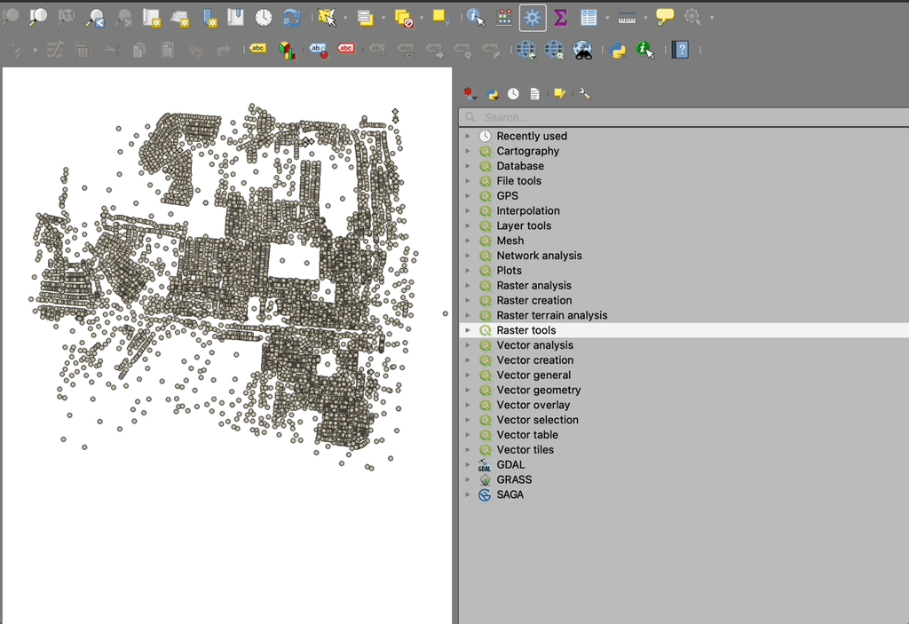

Drop unnecessary fields in QGIS

## Step #2 - Plan Map Interaction:

As covered in the [Lecture Demonstration](https://gis-nspe-tns.github.io/GIS_NINT5423_spring_2023/demos/c2.lecture.demo.html), there are four basic categories of CartoCSS statements:

1. Simple Feature Statements, i.e. the default symbolization and behavior.
2. Zoom Dependent Statements.
3. Attribute Dependent Statements.
4. Classification methods, i.e. ‘TurboCarto’ statements.

Plan your interaction strategy beyond Simple Feature Statements that are standard and accomplished in the styling interface without code. Prompt questions might include:

- At what zoom level should a layer appear/disappear?
- At what zoom level might features change appearance?
- What variables hold important categories for distinction in the map visualization (attribute-dependent statement(s))?
- How best to symbolize both layers together for the final map visualization?

## Step #3 - Enact Map Interaction:

Following your planning strategy for the final map visualization, utilize CartoCSS across both layers to enact the appropriate code. Utilize the CartoCSS references above, the video guide and the in-class lecture demonstration labs to guide your development workflow. Include the following benchmarks in the map visualization:

1. Include at least one Zoom Level Statement.
2. Include at least one Attribute-Dependent Statement.
3. Add a designed popup interaction (covered in video guide).
4. Add a map legend (covered in video guide).
5. Publish map correctly and transfer map link to assignment PDF deliverable.

## Assignment 2 deliverable - CARTO Published Map + Development Synopsis:

- Once your mapping process is complete and you have secured and copied the share link, next create a short synopsis write-up of your assignment 2 map. Discuss the data; where the data originates; what’s important thematically about the data; what was your approach to symbolization of the data. This short write-up can include an image(s) if you wish, but the share link is the ‘proof of work’ requirement. Make sure the share link works as expected, i.e. test it out before inserting into your write-up. Upload the write-up with the map share link to CANVAS for assignment 2 as as `.pdf` document.